# F-test for an ANOVA

## A Mathematical Model

If it is reasonable to assume that the observations from each group are normally distributed, an \(F\)-distribution can be used to approximate the sampling distribution.

Conditions:

- Independent observations within and across groups
- Approximately normal distributions within each group & similar variability across groups
  - Sufficiently “large” samples
  - No extreme outliers

## Test Statistic

The test statistic for an ANOVA \(F\)-test is exactly the **same** as the test statistic as what we use in a randomization test.

- Here, we are assuming that the \(F\)-statistic follows an \(F\)-distribution.

## F-distribution

Under the null hypothesis, an \(F\)-statistic follows an \(F\)-distribution.

This distribution is defined by **two** different degrees of freedom:

1. from the numerator (MSG)
2. from the denominator (MSE)

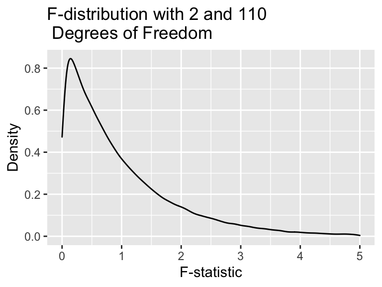

## Degrees of Freedom

Degrees of freedom can be thought of “as how much information is left” when calculating the MSG and MSE.

- For the MSG, we need to know how far each group is from the overall mean.
  - We need to calculate the overall mean.
  - Thus, we have \(k - 1\) degrees of freedom.
- For the MSE, we need to know how far each observation is from its group mean.
  - We need to calculate the \(k\) group means.
  - Thus, we have \(n - k\) degrees of freedom.

- We’re interested in testing to see if the mean bill depth differs across species of penguins in the Palmer Archipelago.

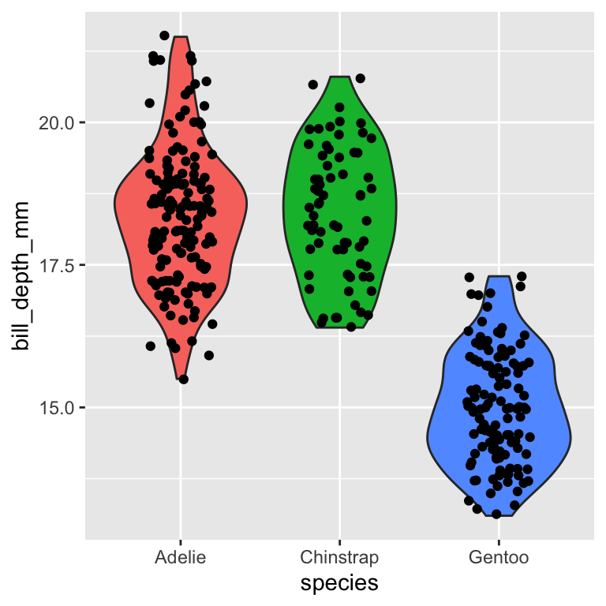

## Model Conditions

- It seems reasonable to assume that the penguins within each species are independent.
- These penguins were not randomly sampled, but it seems reasonable to assume that the observations within a group are independent.
- The distributions have some oddities, but not enough to conclude they violate the normality condition.
- The shapes of the distribution appear relatively similar.
  - The Adelie penguins have more variability in their bill depths, but nothing too outlandish.

## Conducting an ANOVA \(F\)-test

```r
aov(bill_depth_mm ~ species, data = penguins) %>%
  tidy()
```

```
## # A tibble: 2 x 6
##   term         df sumsq meansq statistic   p.value
##   <chr>     <dbl> <dbl>  <dbl>     <dbl>     <dbl>
## 1 species       2  904. 452.        360.  1.51e-84
## 2 Residuals   339  426.   1.26       NA  NA
```